# Project 3

Yaman Yucel

2023-04-17

## Project 3

Part a: Convert the prices into returns for all the 5 stocks. Important note: In this data set the most recent data are at the beginning. You will need to consider this when converting the prices into returns.

```r
a <- read.table("http://www.stat.ucla.edu/~nchristo/statistics_c183_c283/statc183c283_5stocks.txt", header=T)

#Exxon-mobil -> P1
#General Motors -> P2
#Hewlett Packard -> P3
#McDonalds -> P4
#Boeing -> P5


#Reverse the list such that older values appear on top
b<- a[dim(a)[1]:1,]

#Convert adjusted close prices into returns:
r <- (b[-1,2:ncol(b)]-b[-nrow(b),2:ncol(b)])/b[-nrow(b),2:ncol(b)]
```

Part b: Compute the mean return for each stock and the variance-covariance matrix.

```r
#Compute mean vector:
means <- colMeans(r)
print("Means:")
```

```
## [1] "Means:"
```

```r
print(means)
```

```
##           P1           P2           P3           P4           P5
## 0.0027625075 0.0035831363 0.0066229478 0.0004543727 0.0045679106
```

```r
#Compute variance covariance matrix
covmat <- cov(r)
print("Var-Covar:")
```

```
## [1] "Var-Covar:"
```

```r
print(covmat)
```

```
##             P1          P2          P3          P4          P5
## P1 0.005803160 0.001389264 0.001666854 0.000789581 0.001351044
## P2 0.001389264 0.009458804 0.003944643 0.002281200 0.002578939
## P3 0.001666854 0.003944643 0.016293581 0.002863584 0.001469964
## P4 0.000789581 0.002281200 0.002863584 0.009595202 0.003210827
## P5 0.001351044 0.002578939 0.001469964 0.003210827 0.009242440
```

```r
#Compute correlation matrix:
cormat <- cor(r)
print("Correlation:")
```

```
## [1] "Correlation:"
```

```r
print(cormat)
```

```
##           P1        P2        P3        P4        P5
## P1 1.0000000 0.1875142 0.1714182 0.1058126 0.1844777
## P2 0.1875142 1.0000000 0.3177469 0.2394518 0.2758225
## P3 0.1714182 0.3177469 1.0000000 0.2290206 0.1197857
## P4 0.1058126 0.2394518 0.2290206 1.0000000 0.3409545
## P5 0.1844777 0.2758225 0.1197857 0.3409545 1.0000000
```

```r
#Compute the vector of variances:
variances <- diag(covmat)
print("Variances:")
```

```
## [1] "Variances:"
```

```r
print(variances)
```

```
##          P1          P2          P3          P4          P5
## 0.005803160 0.009458804 0.016293581 0.009595202 0.009242440
```

```r
#Compute the vector of standard deviations:
stdev <- diag(covmat)^.5
print("STD")
```

```
## [1] "STD"
```

```r
print(stdev)
```

```
##         P1         P2         P3         P4         P5
## 0.07617847 0.09725638 0.12764631 0.09795510 0.09613761
```

```r
#Compute inverse of variance covariance matrix
inv_covmat <- solve(covmat)
```

Part c: Use only Exxon-Mobil and Boeing stocks: For these 2 stocks find the composition, expected return, and standard deviation of the minimum risk portfolio

```r
ones_2 = rep(1,2)

r_2 = r[c("P1","P5")]

means_2 <- colMeans(r_2)
covmat_2 <- cov(r_2)
stdev_2 <- diag(covmat_2)^.5
inv_covmat_2 <- solve(covmat_2)

min_risk_weight_vector_2 <- inv_covmat_2  %*% ones_2 /as.numeric(t(ones_2)  %*%  inv_covmat_2 %*% ones_2)
min_risk_varp_2 <- t(min_risk_weight_vector_2) %*% covmat_2 %*% min_risk_weight_vector_2
min_risk_Rp_2 <- t(min_risk_weight_vector_2) %*% means_2
min_risk_sigmap_2 <- sqrt(min_risk_varp_2)
print("Composition min-risk portfolio with 2 stocks")
```

```
## [1] "Composition min-risk portfolio with 2 stocks"
```

```r
print(min_risk_weight_vector_2)
```

```
##         [,1]
## P1 0.6393153
## P5 0.3606847
```

```r
print("Mean of min-risk portolio with 2 stocks")
```

```
## [1] "Mean of min-risk portolio with 2 stocks"
```

```r
print(min_risk_Rp_2)
```

```
##             [,1]
## [1,] 0.003413689
```

```r
print("Std of min-risk portolio with 2 stocks")
```

```
## [1] "Std of min-risk portolio with 2 stocks"
```

```r
print(min_risk_sigmap_2)
```

```
##            [,1]
## [1,] 0.06478695
```

Part d : Plot the portfolio possibilities curve and identify the efficient frontier on it

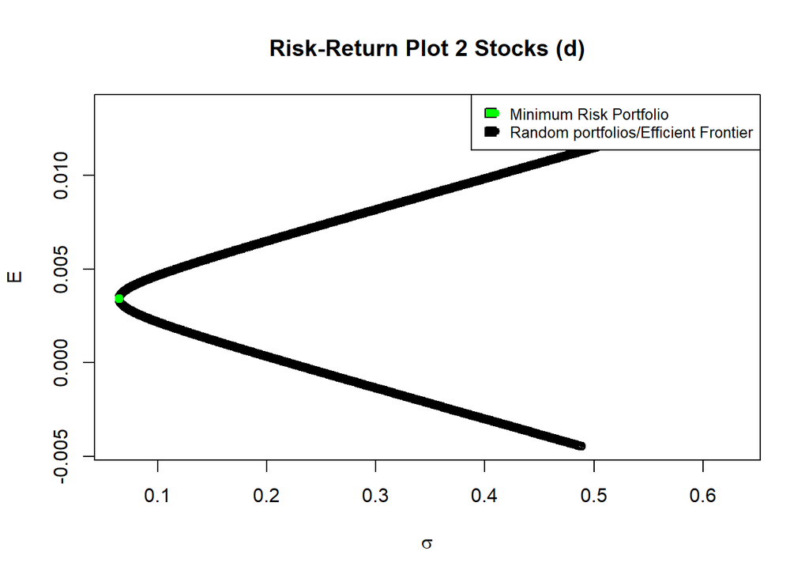

```r
x1 = seq(from = -5,to = 5, by = 0.01)
x2 = 1 - x1
means_plot= rep(0,length(x1))
vars_plot = rep(0,length(x1))
for (i in 1:length(x1)){
  coef_temp = c(x1[i],x2[i])
  means_plot[i] = t(coef_temp) %*% means_2
  vars_plot[i] = t(coef_temp) %*% covmat_2 %*% coef_temp
}
plot(sqrt(vars_plot), means_plot, ylab = 'E', xlab = expression(sigma), main="Risk-Return Plot 2 Stocks (d)")
points(sqrt(min_risk_varp_2), min_risk_Rp_2, pch=19,lwd=1,col="green")
legend("topright",
       legend=c("Minimum Risk Portfolio","Random portfolios/Efficient Frontier"),
       col=c("green","black"),
       pch = 19,
       fill =c("green","black"),
       cex=0.8)
```

Part e: Use only Exxon-Mobil, McDonalds and Boeing stocks and assume short sales are allowed to answer the following question: For these 3 stocks compute the expected return and standard deviation for many combinations of xa, xb, xc with xa + xb + xc = 1 and plot the cloud of points.

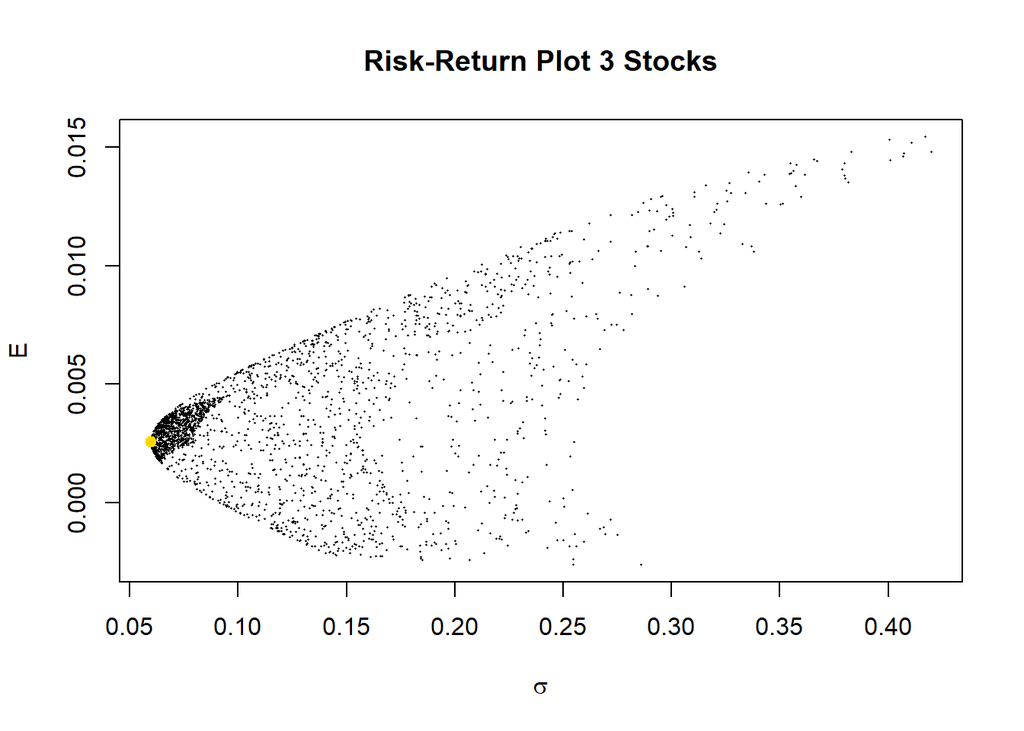

```r
coef_3 <- read.table("http://www.stat.ucla.edu/~nchristo/datac183c283/statc183c283_abc.txt", header=T)

n_samples_3 = dim(coef_3)[1]

ones_3 = rep(1,3)

r_3 = r[c("P1","P4","P5")]

means_3 <- colMeans(r_3)
covmat_3 <- cov(r_3)
stdev_3 <- diag(covmat_3)^.5
inv_covmat_3 <- solve(covmat_3)

min_risk_weight_vector_3 <- inv_covmat_3  %*% ones_3 /as.numeric(t(ones_3)  %*%  inv_covmat_3 %*% ones_3)
min_risk_varp_3 <- t(min_risk_weight_vector_3) %*% covmat_3 %*% min_risk_weight_vector_3
min_risk_Rp_3 <- t(min_risk_weight_vector_3) %*% means_3
min_risk_sigmap_3 <- sqrt(min_risk_varp_3)

means_plot_3 = rep(0,n_samples_3)
vars_plot_3 = rep(0,n_samples_3)
for (i in 1:n_samples_3){
  coef_temp = c(coef_3$a[i],coef_3$b[i],coef_3$c[i])
  means_plot_3[i] = t(coef_temp) %*% means_3
  vars_plot_3[i] = t(coef_temp) %*% covmat_3 %*% coef_temp
}
plot(sqrt(vars_plot_3), means_plot_3,pch=19,cex = 0.2,lwd=0.1,ylab = 'E', xlab = expression(sigma), main="Risk-Return Plot 3 Stocks")
points(min_risk_sigmap_3,min_risk_Rp_3, pch=19,lwd=1,col="gold")
```

PART F AND G SOLVED TOGETHER  
Part f:Assume Rf = 0.001 and that short sales are allowed. Find the composition, expected return and standard deviation of the portfolio of the point of tangency G and draw the tangent to the efficient frontier of question (e).  
Part g: Find the expected return and standard deviation of the portfolio that consists of 60% and G 40% risk free asset. Show this position on the capital allocation line (CAL)

```r
plot(sqrt(vars_plot_3), means_plot_3,pch=19,cex = 0.2,lwd=0.1,ylab = 'E', xlab = expression(sigma), main="Risk-Return Plot 3 Stocks")
points(min_risk_sigmap_3,min_risk_Rp_3, pch=19,lwd=1,col="gold")
R_f = 0.001
R_new = matrix(means_3 - R_f)
z = inv_covmat_3 %*% R_new
lambda_g = ones_3 %*% z
x_G = z / as.numeric(lambda_g) # composition
print("Composition of tangent")
```

```
## [1] "Composition of tangent"
```